# Homework 2

Madeline Berger

1/28/2020

### Analyzing growth model for invasive species with managed hunting

$f(N) = \frac{dN}{dt} = rN(1-\frac{N}{K}) - P(\frac{aN}{1 + ahN})$

**1. Make a graph of dN/dt vs. N, for particular values of the parameters** Use r = 0.05, K = 2000, P = 4, a = 0.01, and h = 0.2.

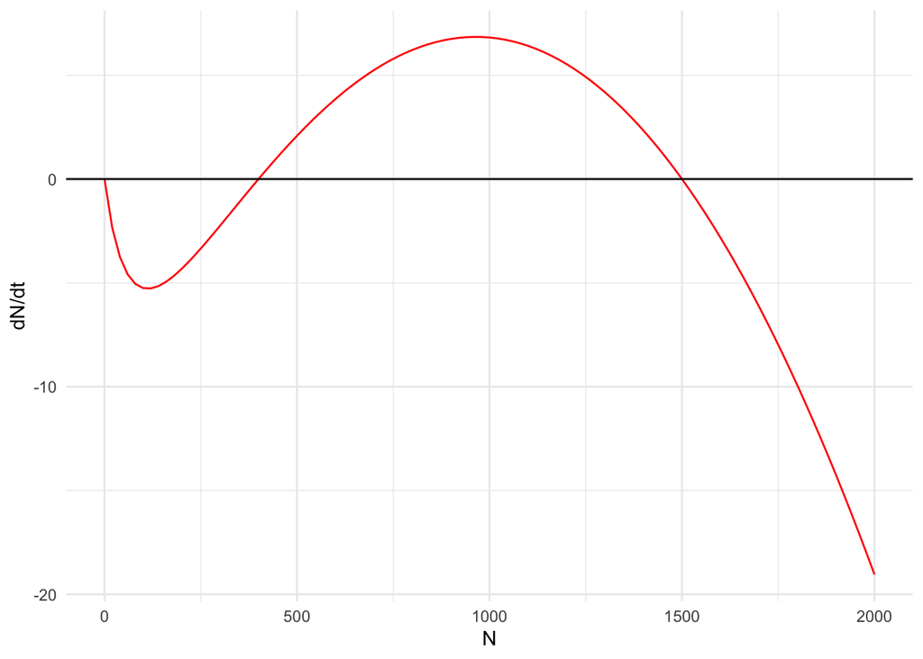

```r
#define parameters

r <- 0.05
K <- 2000
P <- 4
a <- 0.05 #this was changed
h <- 0.2

#write out function
f = function(N){
  r * N * (1 - (N/K)) - P * ((a*N)/(1 + a*h*N))
}

growth_plot <- ggplot(data.frame(N = 0:2000), aes(x = N)) +
  stat_function(fun = "f", color = "red") +
  geom_hline(yintercept = 0) +
  ylab("dN/dt") +
  theme_minimal()

growth_plot
```

**2.Based on this graph, how many equilibria are there? Which ones are stable?**

**3. Returning to the full model with arbitrary parameter values, is there an equilibrium at N = 0 for all plausible parameter values? For what values of hunter number (P), expressed in terms of the other parameters of the model, is the zero equilibrium locally stable? If your goal is to eliminate the insvasive species, what does this tell you about how many hunters you need?**

Looking at the expression, we see algebraically that when N = 0, $\frac{dN}{dt}$ will always be zero regardless of the other parameters, as the first term is multiplied by zero, and the second term has a zero in the denominator reducing the entire expression to zero.

Since we are evaluating this expression at N = 0, the equation becomes:

$\frac{df(N)}{dN} = r-P*a$

The equilibrium is stable when this expression is a negative value. Or when:

$0 = r-P*a$ solving for P:

$P = \frac{r}{a}$

This implies that the number of hunters needed depends both on the growth rate of the invasive species as well as the “per pray attack rate”, which is analagous to the number of shots a hunter takes (??). For example, if the growth rate increases but the hunters do not increase their shots, then more hunters are needed. This might apply to an animal that is difficult to hunt, which wild boars most likely are.

*attack rate = a rate at which the hunter encounters and successfully kills*

```r
#what is the derivative of the model equation? gives you the slope (just to double check my calculations)
dFN <- Deriv(f)

Simplify(dFN)
```

```
## function (N)
## {
##     .e1 <- 1 + a * h * N
##     N * (a^2 * h * P/.e1^2 - r/K) + r * (1 - N/K) - a * P/.e1
## }
```

**4. Write down the equation you would need to solve in order to find the value of any non-zero equilibria. If you enjoy doing algebra, you may use the quadratic formula to find the values of N that satisfy this equation, but that is entirely optional (the result is a rather complicated expression!).**

To find any non-zero equilibria, set the intial equation to zero, and solve for N:

$0 = r*N*(1-\frac{N}{k})-P*(\frac{aN}{1 + ahN})$

**5.Because the algebra is tedious, and the result is so complex that it doesn’t give a lot of insight, it’s useful to do some more graphical analysis. In particular, we break the equation into its two component parts, the intrinsic population growth** $r*N*(1-\frac{N}{k})$ **and hunting** $P*(\frac{aN}{1 + ahN})$

1. Using the same parameters as before, graph both the intrinsic growth rate and hunting rate as functions of N on the same graph.

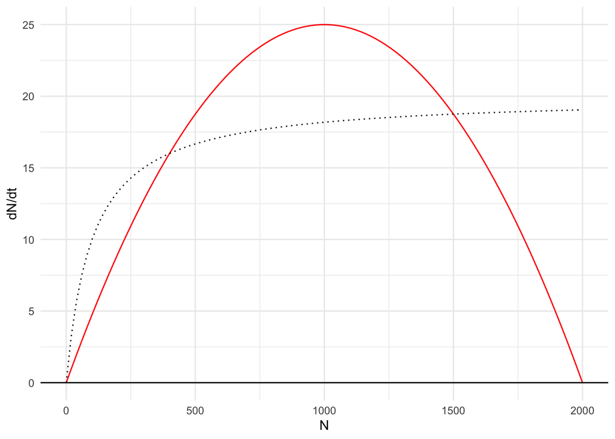

```r
f_growth = function(N) {
  r * N * (1 -(N/K))
  }

f_hunt = function(N, P = 4){
  P * (a*N/(1 + a*h*N))
}

separate_plot <- ggplot(data.frame(N = 0:2000), aes(x = N))+
  stat_function(fun = f_growth, color = "red") +
  stat_function(fun = f_hunt, linetype = "dotted")+
  geom_hline(yintercept = 0) +
  ylab("dN/dt")+
  theme_minimal()


separate_plot
```

**b. What do you expect will happen to the population when the hunting rate is greater than the intrinsic growth rate? When it is less? When they are equal?**

When the hunting rate exceeds the intrinsic growth rate, we would expect the population to decrease. When it is less, the population would be expected to increase. At the point of intersection the population is in equilibrium because birth rate (dn/dt) is equal to mortality (hunting rate)

**c. How do the patterns you see on this graph relate to the ones in problem 1?**

**6. Now make two similar graphs, keeping all the parameters the same but setting P = 1 in one graph and P = 6 in the other. How many equilbria are there in each case, and which are stable?**

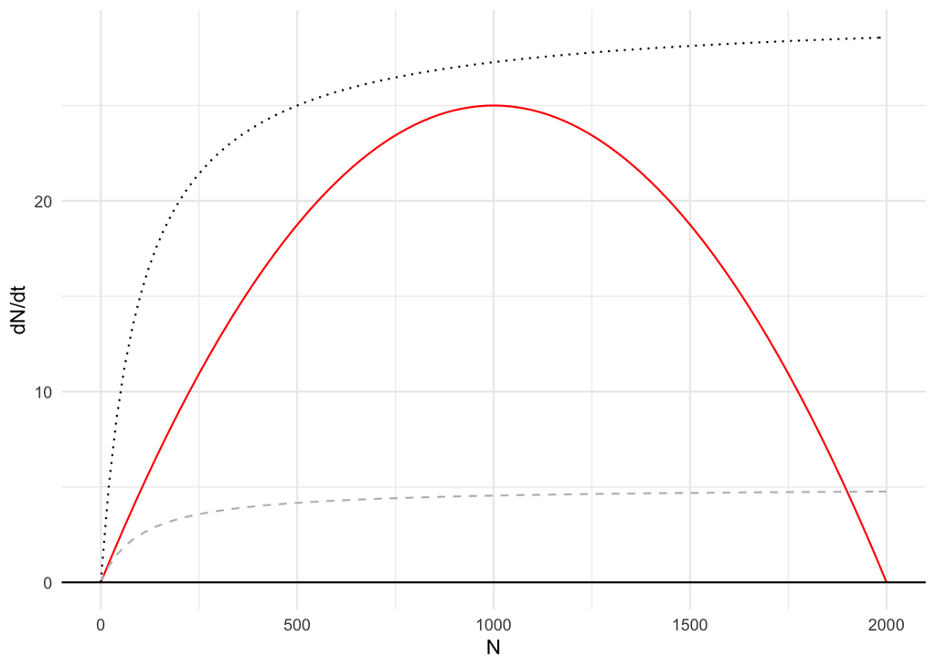

```r
separate_plot <- ggplot(data.frame(N = 0:2000), aes(x = N))+
  stat_function(fun = f_growth, color = "red") +
  stat_function(fun = f_hunt, args = list(P = 1), color = "gray", linetype = "dashed")+
  stat_function(fun = f_hunt, args = list(P = 6), linetype = "dotted")+
  geom_hline(yintercept = 0) +
  ylab("dN/dt")+
  theme_minimal()

separate_plot
```

When P = 6 (six hunters), there is only one equilibrium at N = 0. This makes sense since the hunting rate, which can be though as mortality, always exceeds the birth rate (dN/dt), keeping the population from being able to increase to any stable point beyond zero.

**7. The situation in problem 5 is an example of bistability, like in the strong Allee effect. It has important management implications.**

**a. What is the domain of attraction of the zero equlibrium (approximately—you can estimate it from the graph) b, What is the domain of attraction of the largest equibrium?**

Looking back at the first graph created, from N = 0 to appx N = 400 the population will be attracted to the zero equilibrium since between those values, the growth rate is negative. From 400 to infitinty it will be attracted to N = 1500, a stable equilibrium. This is because the growth rate is positive for any value between N = 400 and N = 1500, causing the population to approach 1500, whereas after N = 1500 the growth rate is negative, causing the population to decrease back towards 1500.

**b. If you noticed the arrival of the species soon after it arrived, and initiated control activities when it had reached N = 100 individuals, would you be able to extirpate it with 4 hunters?**

Yes - From graph 1, when P = 4, N = 100 falls within the domain of attraction of the zero equilibrium. Therefore, even if the population reaches 100 somehow, the growth rate remains negative and the hunters will be able to eliminate the species.

**c. What about if the population was already at carrying capacity when you initiated control activities?**

If the species reaches carrying capacity before any management begins, introducing 4 hunters will help to quell the population slighly by reducing it to N = 1500. However, the population will remain at 1500 as long as the birth rate remains the same and the hunting efficiency (“a”) remains the same as well. This is because populations of invasive species greater than N = 400 occur within the domain of attraction for an equilibrium of 1500, not zero.

Use same parameters

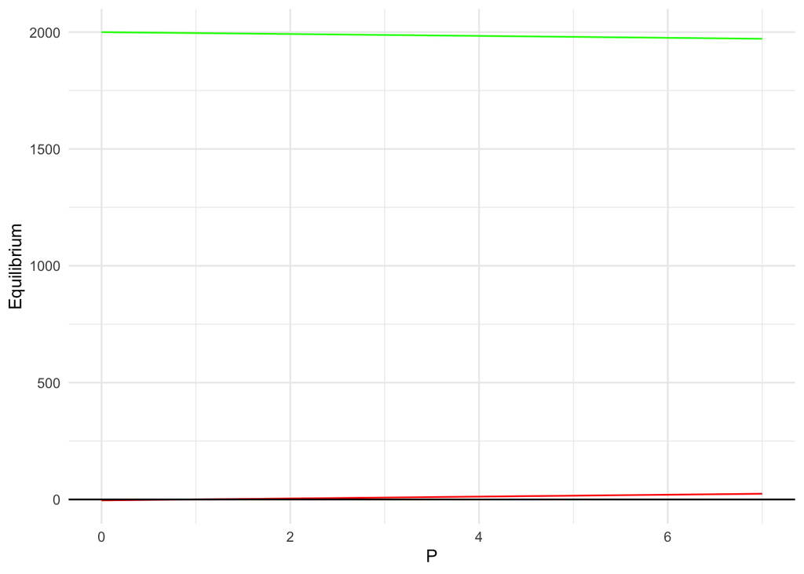

```r
d <- 1/a*h

f_eq_1 <- function(P){
  .5 * ((K - d) - sqrt((K-d)^2 + (4*K*d)/r*(r - a*P)))
}

f_eq_2 <- function(P){
  .5 * ((K - d) + sqrt((K-d)^2 + (4*K*d)/r*(r - a*P)))
}


eq_plot<- ggplot(data.frame(P = 0:7), aes(x = P))+
  stat_function(fun = f_eq_1, color = "red") +
  stat_function(fun = f_eq_2, color = "green")+
  geom_hline(yintercept = 0) +
  ylab("Equilibrium") +
  theme_minimal()

eq_plot
```